# Agricultural Intensification and Settlement Patterns in Tairona Chiefdoms (AD 100–1600): A Multi-Scalar Study of the House-Lot Model in the Sierra Nevada de Santa Marta

Geospatial data sets associated with the Regional Archaeology Program of the Río Frío Basin

Syntax written by [Luis Miguel Soto Rodríguez](https://sites.google.com/view/arch-data-1/home-page) , Ph.D. student at the University of Pittsburgh on April 16, 2026

# 1 Package Loading and Data Input

```r
packages <- c(
  "sf", "terra", "dplyr", "tibble", "ggplot2", "tidyr",
  "spatstat.geom", "spatstat.explore", "spatstat.random", "spatstat",
  "igraph", "patchwork", "ggspatial", "scales", "viridis",
  "vegan", "ggrepel", "knitr", "broom", "ggpubr", "ggsignif"
)

invisible(lapply(packages, function(p) {
  if (!requireNamespace(p, quietly = TRUE)) {
    install.packages(p, dependencies = TRUE)
  }
}))

invisible(lapply(packages, function(p) {
  suppressPackageStartupMessages(library(p, character.only = TRUE))
}))

set.seed(42)
target_crs <- 32618
```

```r
github_base <- "https://raw.githubusercontent.com/luismiguelsoto/Agricultural-Intensification-and-Settlement-Patterns-in-Tairona-Chiefdoms/main/GIS/"
gis_dir <- file.path(tempdir(), "GIS_JASREP")
if (!dir.exists(gis_dir)) dir.create(gis_dir, recursive = TRUE)

gis_files <- c(
  "Neguanje_structures.shp", "Neguanje_structures.shx", "Neguanje_structures.dbf", "Neguanje_structures.prj",
  "Buritaca_structures.shp", "Buritaca_structures.shx", "Buritaca_structures.dbf", "Buritaca_structures.prj",
  "Tairona_structures.shp", "Tairona_structures.shx", "Tairona_structures.dbf", "Tairona_structures.prj",
  "Rio_Frio_Sitios_Neguanje.shp", "Rio_Frio_Sitios_Neguanje.shx", "Rio_Frio_Sitios_Neguanje.dbf", "Rio_Frio_Sitios_Neguanje.prj",
  "Rio_Frio_Sitios_Buritaca.shp", "Rio_Frio_Sitios_Buritaca.shx", "Rio_Frio_Sitios_Buritaca.dbf", "Rio_Frio_Sitios_Buritaca.prj",
  "Rio_Frio_Sitios_Tairona.shp", "Rio_Frio_Sitios_Tairona.shx", "Rio_Frio_Sitios_Tairona.dbf", "Rio_Frio_Sitios_Tairona.prj",
  "Rio_Frio_Limite_Survey.shp", "Rio_Frio_Limite_Survey.shx", "Rio_Frio_Limite_Survey.dbf", "Rio_Frio_Limite_Survey.prj",
  "SOILS_AGRICULTURE_RASTER_52KM.tif"
)

for (f in gis_files) {
  dest <- file.path(gis_dir, f)
  if (!file.exists(dest)) download.file(paste0(github_base, f), dest, mode = "wb", quiet = TRUE)
}

struc_neg <- st_read(file.path(gis_dir, "Neguanje_structures.shp"), quiet = TRUE) %>%
  st_transform(target_crs) %>%
  mutate(Period = "Neguanje")
struc_bur <- st_read(file.path(gis_dir, "Buritaca_structures.shp"), quiet = TRUE) %>%
  st_transform(target_crs) %>%
  mutate(Period = "Buritaca")
struc_tai <- st_read(file.path(gis_dir, "Tairona_structures.shp"), quiet = TRUE) %>%
  st_transform(target_crs) %>%
  mutate(Period = "Tairona")

sites_neg <- st_read(file.path(gis_dir, "Rio_Frio_Sitios_Neguanje.shp"), quiet = TRUE) %>%
  st_transform(target_crs) %>%
  mutate(Period = "Neguanje")
sites_bur <- st_read(file.path(gis_dir, "Rio_Frio_Sitios_Buritaca.shp"), quiet = TRUE) %>%
  st_transform(target_crs) %>%
  mutate(Period = "Buritaca")
sites_tai <- st_read(file.path(gis_dir, "Rio_Frio_Sitios_Tairona.shp"), quiet = TRUE) %>%
  st_transform(target_crs) %>%
  mutate(Period = "Tairona")

survey <- st_read(file.path(gis_dir, "Rio_Frio_Limite_Survey.shp"), quiet = TRUE) %>%
  st_transform(target_crs) %>%
  st_union() %>%
  st_make_valid()

survey_sf <- st_sf(geometry = survey)
survey_union <- survey_sf
soils_r <- terra::rast(file.path(gis_dir, "SOILS_AGRICULTURE_RASTER_52KM.tif"))
A_km2 <- as.numeric(st_area(survey_sf)) / 1e6
A_m2 <- as.numeric(st_area(survey_sf))
periods <- c("Neguanje", "Buritaca", "Tairona")

data_by_period <- list(
  Neguanje = list(structures = struc_neg, sites = sites_neg),
  Buritaca = list(structures = struc_bur, sites = sites_bur),
  Tairona = list(structures = struc_tai, sites = sites_tai)
)
```

# 2 Killion Metrics and Soil Quality

```r
compute_killion_metrics_with_soil <- function(struc_sf, soils_raster) {
  coords <- st_coordinates(struc_sf)
  n <- nrow(struc_sf)
  diameters <- struc_sf$Diam_Terra
  D <- as.matrix(dist(coords))
  diag(D) <- Inf
  NND <- numeric(n)
  NN_idx <- integer(n)
  Available_Space <- numeric(n)

  for (i in seq_len(n)) {
    nn_i <- which.min(D[i, ])
    NND[i] <- D[i, nn_i]
    NN_idx[i] <- nn_i
    Available_Space[i] <- max(0, NND[i] - diameters[i] / 2 - diameters[nn_i] / 2)
  }

  v_pts <- terra::project(terra::vect(struc_sf), terra::crs(soils_raster))
  soil_val <- terra::extract(soils_raster, v_pts, ID = FALSE)
  struc_sf$NNDist <- NND
  struc_sf$NN_Index <- NN_idx
  struc_sf$Available_Space <- Available_Space
  struc_sf$Core_Area <- pi * (diameters / 2)^2
  struc_sf$Soil_Quality <- soil_val[[1]]
  struc_sf$Soil_Category <- cut(
    struc_sf$Soil_Quality,
    breaks = c(0, 2, 4, 6),
    labels = c("Low (1-2)", "Medium (3-4)", "High (5-6)"),
    include.lowest = TRUE
  )
  struc_sf$log_AvailSpace <- log(Available_Space + 1)
  struc_sf$Space_Core_Ratio <- Available_Space / (pi * (diameters / 2)^2 + 1)
  struc_sf
}

struc_neg <- compute_killion_metrics_with_soil(struc_neg, soils_r)
struc_bur <- compute_killion_metrics_with_soil(struc_bur, soils_r)
struc_tai <- compute_killion_metrics_with_soil(struc_tai, soils_r)

data_by_period$Neguanje$structures <- struc_neg
data_by_period$Buritaca$structures <- struc_bur
data_by_period$Tairona$structures <- struc_tai
all_structures <- bind_rows(struc_neg, struc_bur, struc_tai)
all_structures$Period <- factor(all_structures$Period, levels = periods)
```

# 3 Robust Reporting Rules

```r
fmt_p <- function(p, digits = 4) {
  ifelse(is.na(p), NA_character_, ifelse(p < 0.001, "<0.001", format(signif(p, digits), scientific = FALSE)))
}

fmt_pm <- function(mean_value, sd_value, digits = 2) {
  paste0(round(mean_value, digits), " ± ", round(sd_value, digits))
}

fmt_iqr <- function(median_value, iqr_value, digits = 2) {
  paste0(round(median_value, digits), " (", round(iqr_value, digits), ")")
}

tukey_outlier_stats <- function(x) {
  x <- x[is.finite(x)]
  n <- length(x)
  if (n < 4) {
    return(list(n_outliers = 0, prop_outliers = 0, lower_fence = NA_real_, upper_fence = NA_real_))
  }
  q1 <- as.numeric(quantile(x, 0.25, na.rm = TRUE, names = FALSE, type = 7))
  q3 <- as.numeric(quantile(x, 0.75, na.rm = TRUE, names = FALSE, type = 7))
  iqr <- q3 - q1
  lower_fence <- q1 - 1.5 * iqr
  upper_fence <- q3 + 1.5 * iqr
  n_outliers <- sum(x < lower_fence | x > upper_fence, na.rm = TRUE)
  list(n_outliers = n_outliers, prop_outliers = n_outliers / n, lower_fence = lower_fence, upper_fence = upper_fence)
}

shapiro_p_value <- function(x) {
  x <- x[is.finite(x)]
  n <- length(x)
  if (n < 3) return(NA_real_)
  if (length(unique(x)) < 3) return(0)
  if (n > 5000) {
    set.seed(42)
    x <- sample(x, 5000)
  }
  tryCatch(stats::shapiro.test(x)$p.value, error = function(e) NA_real_)
}

skewness_value <- function(x) {
  x <- x[is.finite(x)]
  n <- length(x)
  if (n < 3) return(NA_real_)
  s <- stats::sd(x)
  if (!is.finite(s) || s == 0) return(0)
  mean(((x - mean(x)) / s)^3)
}

trimmed_sd <- function(x, trim = 0.10) {
  x <- sort(x[is.finite(x)])
  n <- length(x)
  if (n < 4) return(stats::sd(x, na.rm = TRUE))
  g <- ceiling(trim * n)
  if ((n - 2 * g) < 2) return(stats::sd(x, na.rm = TRUE))
  xw <- x
  if (g > 0) {
    xw[seq_len(g)] <- x[g + 1]
    xw[(n - g + 1):n] <- x[n - g]
  }
  s2w <- stats::var(xw)
  n_trimmed <- n - 2 * g
  sqrt(((n - 1) * s2w) / (n_trimmed - 1))
}

select_drennan_summary <- function(x, trim = 0.10, normal_alpha = 0.05) {
  x <- x[is.finite(x)]
  n <- length(x)
  if (n == 0) {
    return(list(method = "No_Data", center = NA_real_, spread = NA_real_, center_label = NA_character_, spread_label = NA_character_, shapiro_p = NA_real_, skewness = NA_real_, outlier_prop = NA_real_, zero_prop = NA_real_))
  }

  shapiro_p <- shapiro_p_value(x)
  skew <- skewness_value(x)
  out <- tukey_outlier_stats(x)
  zero_prop <- mean(x == 0, na.rm = TRUE)
  method <- "Mean_SD"

  if (n < 5) {
    method <- "Median_IQR"
  } else if (is.finite(zero_prop) && zero_prop >= 0.10) {
    method <- "Median_IQR"
  } else if (is.finite(out$prop_outliers) && out$prop_outliers >= 0.10) {
    method <- "Median_IQR"
  } else if (is.finite(skew) && abs(skew) >= 1.25) {
    method <- "Median_IQR"
  } else if (is.finite(shapiro_p) && shapiro_p < 0.001) {
    method <- "Median_IQR"
  } else if ((is.finite(out$prop_outliers) && out$prop_outliers > 0) ||
             (is.finite(skew) && abs(skew) >= 0.50) ||
             (is.finite(shapiro_p) && shapiro_p < normal_alpha)) {
    method <- "TrimmedMean_TrimmedSD"
  }

  if (method == "Mean_SD") {
    center <- mean(x, na.rm = TRUE)
    spread <- stats::sd(x, na.rm = TRUE)
    center_label <- "Mean"
    spread_label <- "SD"
  } else if (method == "TrimmedMean_TrimmedSD") {
    center <- mean(x, trim = trim, na.rm = TRUE)
    spread <- trimmed_sd(x, trim = trim)
    center_label <- paste0(trim * 100, "% trimmed mean")
    spread_label <- paste0(trim * 100, "% trimmed SD")
  } else {
    center <- stats::median(x, na.rm = TRUE)
    spread <- stats::IQR(x, na.rm = TRUE)
    center_label <- "Median"
    spread_label <- "IQR/midspread"
  }

  list(
    method = method,
    center = center,
    spread = spread,
    center_label = center_label,
    spread_label = spread_label,
    shapiro_p = shapiro_p,
    skewness = skew,
    outlier_prop = out$prop_outliers,
    zero_prop = zero_prop
  )
}

drennan_center <- function(x) {
  select_drennan_summary(x)$center
}

kw_epsilon_squared <- function(kw, n, k) {
  value <- (as.numeric(kw$statistic) - k + 1) / (n - k)
  max(0, value)
}
```

# 4 Data Integrity and Reporting Diagnostic

```r
cat("======================================================================\n")
cat("DATA INTEGRITY AND ROBUST REPORTING DIAGNOSTIC\n")
```

```
## DATA INTEGRITY AND ROBUST REPORTING DIAGNOSTIC
```

```r
cat("======================================================================\n")
for (period in periods) {
  df <- st_drop_geometry(data_by_period[[period]]$structures)
  auto_avail <- select_drennan_summary(df$Available_Space)
  auto_diam <- select_drennan_summary(df$Diam_Terra)
  cat(sprintf(
    "%s (N=%d): NA_Soil=%d, NA_Avail=%d, Zero_Avail=%d (%.1f%%), Available_Space_Report=%s, Diameter_Report=%s\n",
    period,
    nrow(df),
    sum(is.na(df$Soil_Quality)),
    sum(is.na(df$Available_Space)),
    sum(df$Available_Space == 0, na.rm = TRUE),
    100 * sum(df$Available_Space == 0, na.rm = TRUE) / nrow(df),
    auto_avail$method,
    auto_diam$method
  ))
}
```

```
## Neguanje (N=365): NA_Soil=0, NA_Avail=0, Zero_Avail=41 (11.2%), Available_Space_Report=Median_IQR, Diameter_Report=Median_IQR
## Buritaca (N=319): NA_Soil=0, NA_Avail=0, Zero_Avail=34 (10.7%), Available_Space_Report=Median_IQR, Diameter_Report=Median_IQR
## Tairona (N=2526): NA_Soil=0, NA_Avail=0, Zero_Avail=656 (26.0%), Available_Space_Report=Median_IQR, Diameter_Report=Median_IQR
```

# 5 TABLE 1

```r
compute_period_stats <- function(struc_sf, period_name, survey_area_km2) {
  n <- nrow(struc_sf)
  NND <- struc_sf$NNDist
  MNND <- mean(NND, na.rm = TRUE)
  lambda <- n / (survey_area_km2 * 1e6)
  R_index <- MNND / (0.5 / sqrt(lambda))

  tibble(
    Period = period_name,
    `N structures` = format(n, big.mark = ","),
    `Density/km2` = round(n / survey_area_km2, 2),
    `Diameter mean ± SD (m)` = fmt_pm(mean(struc_sf$Diam_Terra, na.rm = TRUE), sd(struc_sf$Diam_Terra, na.rm = TRUE), 2),
    `Diameter median (IQR) (m)` = fmt_iqr(median(struc_sf$Diam_Terra, na.rm = TRUE), IQR(struc_sf$Diam_Terra, na.rm = TRUE), 2),
    `NND mean ± SD (m)` = fmt_pm(mean(NND, na.rm = TRUE), sd(NND, na.rm = TRUE), 2),
    `NND median (IQR) (m)` = fmt_iqr(median(NND, na.rm = TRUE), IQR(NND, na.rm = TRUE), 2),
    `Clark-Evans R` = round(R_index, 4),
    `Available space mean ± SD (m)` = fmt_pm(mean(struc_sf$Available_Space, na.rm = TRUE), sd(struc_sf$Available_Space, na.rm = TRUE), 1),
    `Available space median (IQR) (m)` = fmt_iqr(median(struc_sf$Available_Space, na.rm = TRUE), IQR(struc_sf$Available_Space, na.rm = TRUE), 1),
    `Zero clearance n (%)` = paste0(
      sum(struc_sf$Available_Space == 0, na.rm = TRUE),
      " (",
      round(100 * mean(struc_sf$Available_Space == 0, na.rm = TRUE), 1),
      "%)"
    ),
    `Soil quality mean` = round(mean(struc_sf$Soil_Quality, na.rm = TRUE), 2),
    `Soil quality median (IQR)` = fmt_iqr(median(struc_sf$Soil_Quality, na.rm = TRUE), IQR(struc_sf$Soil_Quality, na.rm = TRUE), 0)
  )
}

table1 <- bind_rows(
  compute_period_stats(struc_neg, "Neguanje", A_km2),
  compute_period_stats(struc_bur, "Buritaca", A_km2),
  compute_period_stats(struc_tai, "Tairona", A_km2)
)

knitr::kable(
  table1,
  caption = "TABLE 1: Settlement demography, terrace size, spacing, and robust descriptive summaries.",
  align = "c"
)
```

TABLE 1: Settlement demography, terrace size, spacing, and robust descriptive summaries.

| Period | N structures | Density/km2 | Diameter mean ± SD (m) | Diameter median (IQR) (m) | NND mean ± SD (m) | NND median (IQR) (m) | Clark-Evans R | Available space mean ± SD (m) | Available space median (IQR) (m) | Zero clearance n (%) | Soil quality mean | Soil quality median (IQR) |
| --- | --- | --- | --- | --- | --- | --- | --- | --- | --- | --- | --- | --- |
| Neguanje | 365 | 6.99 | 10.56 ± 2.48 | 10 (3) | 83.39 ± 147.05 | 35.69 (72.19) | 0.4410 | 73.2 ± 146.9 | 25.3 (73.6) | 41 (11.2%) | 4.10 | 4 (2) |
| Buritaca | 319 | 6.11 | 10.67 ± 2.88 | 10 (3) | 89.61 ± 157.14 | 38.64 (77.1) | 0.4430 | 79.2 ± 156.9 | 28.1 (78.3) | 34 (10.7%) | 4.13 | 4 (3) |
| Tairona | 2,526 | 48.39 | 10.65 ± 2.95 | 10 (3) | 26.91 ± 40.69 | 17.12 (19.19) | 0.3744 | 17.4 ± 40.1 | 6.7 (19.1) | 656 (26%) | 4.48 | 5 (3) |

```r
cat("\nDiagnostic note for Table 1 (not a manuscript table):\n")
```

Diagnostic note for Table 1 (not a manuscript table):

```r
for (period in periods) {
  df <- st_drop_geometry(data_by_period[[period]]$structures)
  variables <- list(
    `Terrace diameter` = df$Diam_Terra,
    `Nearest neighbor distance` = df$NNDist,
    `Available space` = df$Available_Space,
    `Space-core ratio` = df$Space_Core_Ratio
  )
  cat(sprintf("\n%s\n", toupper(period)))
  for (nm in names(variables)) {
    d <- select_drennan_summary(variables[[nm]])
    cat(sprintf(
      "%s: recommended=%s, center=%.3f, spread=%.3f, skewness=%.3f, outliers=%.1f%%, zeros=%.1f%%\n",
      nm,
      d$method,
      d$center,
      d$spread,
      d$skewness,
      100 * d$outlier_prop,
      100 * d$zero_prop
    ))
  }
}
```

[output not shown]

NEGUANJE Terrace diameter: recommended=Median_IQR, center=10.000, spread=3.000, skewness=1.947, outliers=1.6%, zeros=0.0% Nearest neighbor distance: recommended=Median_IQR, center=35.693, spread=72.194, skewness=5.596, outliers=10.1%, zeros=0.0% Available space: recommended=Median_IQR, center=25.341, spread=73.620, skewness=5.617, outliers=9.0%, zeros=11.2% Space-core ratio: recommended=Median_IQR, center=0.305, spread=0.822, skewness=5.314, outliers=11.0%, zeros=11.2%

BURITACA Terrace diameter: recommended=Median_IQR, center=10.000, spread=3.000, skewness=3.238, outliers=2.2%, zeros=0.0% Nearest neighbor distance: recommended=Median_IQR, center=38.639, spread=77.099, skewness=5.157, outliers=10.3%, zeros=0.0% Available space: recommended=Median_IQR, center=28.123, spread=78.297, skewness=5.166, outliers=10.3%, zeros=10.7% Space-core ratio: recommended=Median_IQR, center=0.316, spread=0.936, skewness=5.152, outliers=10.7%, zeros=10.7%

# 6 TABLE 2

```r
extract_group_stat <- function(stats_df, group_name, value_name) {
  out <- stats_df %>%
    filter(Soil_Category == group_name) %>%
    pull(all_of(value_name))
  if (length(out) == 0) NA_real_ else out[1]
}

run_killion_soil_test <- function(struc_sf, period_name) {
  df <- st_drop_geometry(struc_sf) %>%
    filter(!is.na(Soil_Quality), !is.na(Available_Space), Available_Space >= 0, !is.na(Soil_Category))

  sp <- suppressWarnings(cor.test(df$Soil_Quality, df$Available_Space, method = "spearman", exact = FALSE))
  kw <- kruskal.test(Available_Space ~ Soil_Category, data = df)
  k <- n_distinct(df$Soil_Category)
  eps2 <- kw_epsilon_squared(kw, nrow(df), k)

  stats <- df %>%
    group_by(Soil_Category) %>%
    summarise(
      n = n(),
      median = median(Available_Space, na.rm = TRUE),
      iqr = IQR(Available_Space, na.rm = TRUE),
      zeros = sum(Available_Space == 0, na.rm = TRUE),
      .groups = "drop"
    )

  tibble(
    Period = period_name,
    N = format(nrow(df), big.mark = ","),
    `Spearman rho` = round(as.numeric(sp$estimate), 4),
    `Spearman p` = fmt_p(sp$p.value),
    `Kruskal-Wallis H` = round(as.numeric(kw$statistic), 2),
    df = as.numeric(kw$parameter),
    `KW p` = fmt_p(kw$p.value),
    `KW epsilon2` = round(eps2, 4),
    `Low median (IQR)` = fmt_iqr(extract_group_stat(stats, "Low (1-2)", "median"), extract_group_stat(stats, "Low (1-2)", "iqr"), 1),
    `Medium median (IQR)` = fmt_iqr(extract_group_stat(stats, "Medium (3-4)", "median"), extract_group_stat(stats, "Medium (3-4)", "iqr"), 1),
    `High median (IQR)` = fmt_iqr(extract_group_stat(stats, "High (5-6)", "median"), extract_group_stat(stats, "High (5-6)", "iqr"), 1),
    `Zero clearance low/medium/high` = paste0(
      extract_group_stat(stats, "Low (1-2)", "zeros"), "/",
      extract_group_stat(stats, "Medium (3-4)", "zeros"), "/",
      extract_group_stat(stats, "High (5-6)", "zeros")
    )
  )
}

table2 <- bind_rows(
  run_killion_soil_test(struc_neg, "Neguanje"),
  run_killion_soil_test(struc_bur, "Buritaca"),
  run_killion_soil_test(struc_tai, "Tairona")
)

knitr::kable(
  table2,
  caption = "TABLE 2: Rank-based tests of soil quality and available space with resistant summaries and effect sizes.",
  align = "c"
)
```

TABLE 2: Rank-based tests of soil quality and available space with resistant summaries and effect sizes.

| Period | N | Spearman rho | Spearman p | Kruskal-Wallis H | df | KW p | KW epsilon2 | Low median (IQR) | Medium median (IQR) | High median (IQR) | Zero clearance low/medium/high |
| --- | --- | --- | --- | --- | --- | --- | --- | --- | --- | --- | --- |
| Neguanje | 365 | 0.2546 | <0.001 | 26.82 | 2 | <0.001 | 0.0686 | 17.5 (47.8) | 17.1 (39.6) | 41.1 (115.9) | 7/23/11 |
| Buritaca | 319 | 0.1744 | 0.001763 | 11.02 | 2 | 0.004037 | 0.0286 | 17.6 (54.8) | 20.1 (65.3) | 41.1 (95.4) | 8/17/9 |
| Tairona | 2,526 | -0.0854 | <0.001 | 17.19 | 2 | <0.001 | 0.0060 | 8.5 (20.2) | 7.7 (19.9) | 5.6 (17.7) | 73/170/413 |

```r
cat("\nPairwise Wilcoxon rank-sum tests with Holm-adjusted p-values (not a manuscript table):\n")
```

Pairwise Wilcoxon rank-sum tests with Holm-adjusted p-values (not a manuscript table):

```r
for (period in periods) {
  df <- st_drop_geometry(data_by_period[[period]]$structures) %>%
    filter(!is.na(Soil_Quality), !is.na(Available_Space), Available_Space >= 0, !is.na(Soil_Category))
  pw <- pairwise.wilcox.test(df$Available_Space, df$Soil_Category, p.adjust.method = "holm", exact = FALSE)
  cat(sprintf("\n%s\n", toupper(period)))
  for (r in rownames(pw$p.value)) {
    for (cc in colnames(pw$p.value)) {
      pv <- pw$p.value[r, cc]
      if (!is.na(pv)) cat(sprintf("%s vs %s: p=%s\n", r, cc, fmt_p(pv)))
    }
  }
}
```

NEGUANJE Medium (3-4) vs Low (1-2): p=0.7909 High (5-6) vs Low (1-2): p=<0.001 High (5-6) vs Medium (3-4): p=<0.001

BURITACA Medium (3-4) vs Low (1-2): p=0.4995 High (5-6) vs Low (1-2): p=0.01052 High (5-6) vs Medium (3-4): p=0.02116

TAIRONA Medium (3-4) vs Low (1-2): p=0.3325 High (5-6) vs Low (1-2): p=0.002127 High (5-6) vs Medium (3-4): p=0.003029

```r
run_auto_group_comparison <- function(data, response, group, label) {
  df <- data %>%
    st_drop_geometry() %>%
    select(all_of(c(response, group))) %>%
    filter(is.finite(.data[[response]]), !is.na(.data[[group]]))

  overall <- select_drennan_summary(df[[response]])
  kw <- kruskal.test(stats::as.formula(paste(response, "~", group)), data = df)
  eps2 <- kw_epsilon_squared(kw, nrow(df), n_distinct(df[[group]]))

  cat(sprintf(
    "%s: recommended summary=%s; Kruskal-Wallis H=%.3f, df=%d, p=%s, epsilon2=%.4f\n",
    label,
    overall$method,
    as.numeric(kw$statistic),
    as.numeric(kw$parameter),
    fmt_p(kw$p.value),
    eps2
  ))
}

cat("\nDiachronic diagnostic used for interpretation only (not a manuscript table):\n")
```

Diachronic diagnostic used for interpretation only (not a manuscript table):

```r
run_auto_group_comparison(all_structures, "Diam_Terra", "Period", "Terrace diameter")
```

Terrace diameter: recommended summary=Median_IQR; Kruskal-Wallis H=0.073, df=2, p=0.9641, epsilon2=0.0000

```r
run_auto_group_comparison(all_structures, "NNDist", "Period", "Nearest neighbor distance")
```

Nearest neighbor distance: recommended summary=Median_IQR; Kruskal-Wallis H=329.435, df=2, p=<0.001, epsilon2=0.1021

```r
run_auto_group_comparison(all_structures, "Available_Space", "Period", "Available space")
```

Available space: recommended summary=Median_IQR; Kruskal-Wallis H=319.371, df=2, p=<0.001, epsilon2=0.0990

```r
run_auto_group_comparison(all_structures, "Space_Core_Ratio", "Period", "Space-core ratio")
```

Space-core ratio: recommended summary=Median_IQR; Kruskal-Wallis H=292.133, df=2, p=<0.001, epsilon2=0.0905

```r
run_auto_group_comparison(all_structures, "Core_Area", "Period", "Core area")
```

Core area: recommended summary=Median_IQR; Kruskal-Wallis H=0.073, df=2, p=0.9641, epsilon2=0.0000

# 7 FIGURE 3: B Coefficient and Soil Suitability

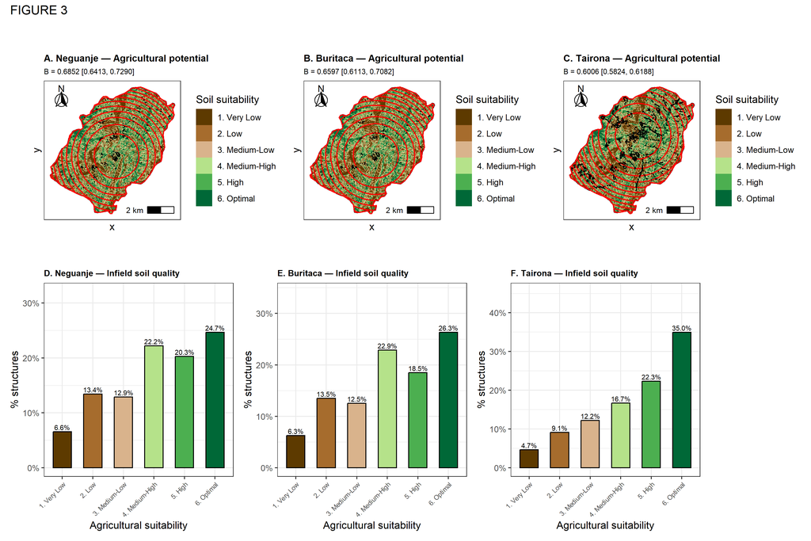

FIGURE 3: Agricultural potential, equal-area rings, B coefficient, and soil suitability by period.

```r
soil_labels <- c("1. Very Low", "2. Low", "3. Medium-Low", "4. Medium-High", "5. High", "6. Optimal")
soil_colors <- c("#5D3A00", "#A66C2D", "#D9B38C", "#B5E28A", "#4CAF50", "#006837")
cls_levels <- sort(unique(terra::values(soils_r, na.rm = TRUE)))
cls_levels <- cls_levels[is.finite(cls_levels)]
if (length(cls_levels) > length(soil_labels)) cls_levels <- cls_levels[seq_len(length(soil_labels))]
levels_map <- setNames(soil_labels[seq_len(length(cls_levels))], as.character(cls_levels))
cols_map_labels <- setNames(soil_colors[seq_len(length(cls_levels))], unname(levels_map))

df_ras <- as.data.frame(soils_r, xy = TRUE, na.rm = TRUE)
colnames(df_ras) <- c("x", "y", "class")
df_ras <- df_ras[is.finite(df_ras$class), ]
df_ras$class <- factor(df_ras$class, levels = cls_levels, labels = unname(levels_map))

B_params <- list(
  Neguanje = list(n_rings = 12, dist_max = 5826.215, center_x = 599236, center_y = 1211131),
  Buritaca = list(n_rings = 12, dist_max = 5847.356, center_x = 599202, center_y = 1211180),
  Tairona = list(n_rings = 12, dist_max = 5992.292, center_x = 599413, center_y = 1212647)
)

B_results <- list()
soil_results <- list()

for (period in periods) {
  params <- B_params[[period]]
  struc_sf <- data_by_period[[period]]$structures
  area_per_ring <- A_m2 / params$n_rings
  cum_areas <- cumsum(rep(area_per_ring, params$n_rings))
  radii <- sqrt(cum_areas / pi)
  radii_scaled <- radii * (params$dist_max / max(radii))
  center_pt <- st_sfc(st_point(c(params$center_x, params$center_y)), crs = st_crs(survey_union))
  rings_list <- vector("list", params$n_rings)

  for (j in seq_len(params$n_rings)) {
    outer <- st_buffer(center_pt, dist = radii_scaled[j])
    ring_geom <- if (j == 1) outer else suppressWarnings(st_difference(outer, st_buffer(center_pt, dist = radii_scaled[j - 1])))
    rings_list[[j]] <- st_collection_extract(st_make_valid(suppressWarnings(st_intersection(ring_geom, survey_union))), "POLYGON", warn = FALSE)
  }

  valid_rings <- Filter(function(x) !st_is_empty(x) && length(x) > 0, rings_list)
  rings_sf <- do.call(rbind, lapply(seq_along(valid_rings), function(k) st_sf(geometry = valid_rings[[k]], ring = k))) %>%
    st_make_valid()
  counts <- sapply(valid_rings, function(r) sum(st_within(struc_sf, r, sparse = FALSE)))
  rings_sf$count <- as.integer(counts)
  total <- sum(counts)
  table_rings <- data.frame(Ring = rings_sf$ring, Count = rings_sf$count, Prop = rings_sf$count / total)
  w <- rev(seq_len(nrow(table_rings)))
  B <- (100 * sum(w * table_rings$Prop) - 650) / 550
  wp <- sum(w * table_rings$Prop)
  var_wp <- max(0, (sum((w^2) * table_rings$Prop) - wp^2) / total)
  se_B <- (100 / 550) * sqrt(var_wp)
  B95 <- 1.96 * se_B
  B_results[[period]] <- list(B = B, B_ci = c(B - B95, B + B95), rings_sf = rings_sf, total = total)

  pbc <- as.data.frame(table(struc_sf$Soil_Quality))
  colnames(pbc) <- c("class", "n")
  pbc$class <- factor(pbc$class, levels = cls_levels, labels = unname(levels_map))
  pbc$prop <- pbc$n / sum(pbc$n)
  soil_results[[period]] <- list(prop_by_class = pbc)
}

soil_map_plots <- list()
soil_prop_plots <- list()
for (i in seq_along(periods)) {
  period <- periods[i]
  res_B <- B_results[[period]]
  sites_sf <- data_by_period[[period]]$sites

  soil_map_plots[[period]] <- ggplot() +
    geom_raster(data = df_ras, aes(x = x, y = y, fill = class)) +
    geom_sf(data = survey_union, fill = NA, color = "black", linetype = "dashed", linewidth = 0.8) +
    geom_sf(data = res_B$rings_sf, fill = NA, color = "red", linewidth = 0.6) +
    geom_sf(data = sites_sf, fill = "black", color = "black", linewidth = 0.25) +
    coord_sf(datum = NA) +
    scale_fill_manual(values = cols_map_labels, drop = FALSE, name = "Soil suitability") +
    ggspatial::annotation_north_arrow(location = "tl", style = north_arrow_fancy_orienteering(), height = unit(0.8, "cm"), width = unit(0.8, "cm")) +
    ggspatial::annotation_scale(location = "br", unit_category = "metric") +
    labs(title = paste0(LETTERS[i], ". ", period, " — Agricultural potential"), subtitle = sprintf("B = %.4f [%.4f, %.4f]", res_B$B, res_B$B_ci[1], res_B$B_ci[2])) +
    theme_bw() +
    theme(legend.position = "right", plot.title = element_text(face = "bold", size = 10), plot.subtitle = element_text(size = 8), axis.text = element_blank(), axis.ticks = element_blank())

  res <- soil_results[[period]]
  soil_prop_plots[[period]] <- ggplot(res$prop_by_class, aes(x = class, y = prop, fill = class)) +
    geom_col(color = "black", width = 0.6) +
    geom_text(aes(label = scales::percent(prop, accuracy = 0.1)), vjust = -0.35, size = 2.5) +
    scale_y_continuous(labels = scales::percent, limits = c(0, max(res$prop_by_class$prop) * 1.3)) +
    scale_fill_manual(values = cols_map_labels, drop = FALSE) +
    guides(fill = "none") +
    labs(title = paste0(LETTERS[i + 3], ". ", period, " — Infield soil quality"), x = "Agricultural suitability", y = "% structures") +
    theme_bw() +
    theme(plot.title = element_text(face = "bold", size = 9), axis.text.x = element_text(angle = 45, hjust = 1, size = 7))
}

fig3 <- (soil_map_plots$Neguanje | soil_map_plots$Buritaca | soil_map_plots$Tairona) /
  (soil_prop_plots$Neguanje | soil_prop_plots$Buritaca | soil_prop_plots$Tairona) +
  plot_annotation(title = "FIGURE 3")
print(fig3)
```

```r
soil_contingency <- data.frame(Class = soil_labels, Neguanje = 0, Buritaca = 0, Tairona = 0)
for (period in periods) {
  res <- soil_results[[period]]
  for (j in seq_len(nrow(res$prop_by_class))) {
    idx <- which(soil_contingency$Class == as.character(res$prop_by_class$class[j]))
    if (length(idx) > 0) soil_contingency[idx, period] <- res$prop_by_class$n[j]
  }
}
soil_matrix <- as.matrix(soil_contingency[rowSums(soil_contingency[, -1]) > 0, -1])
chi_soils <- chisq.test(soil_matrix)
cramer_v <- sqrt(as.numeric(chi_soils$statistic) / (sum(soil_matrix) * (min(dim(soil_matrix)) - 1)))
cat(sprintf("Chi-square=%.2f, df=%d, p=%s, Cramer's V=%.4f\n", as.numeric(chi_soils$statistic), as.numeric(chi_soils$parameter), fmt_p(chi_soils$p.value), cramer_v))
```

```
## Chi-square=40.82, df=10, p=<0.001, Cramer's V=0.0797
```

# 8 FIGURE 4: Available Space by Soil Category and Period

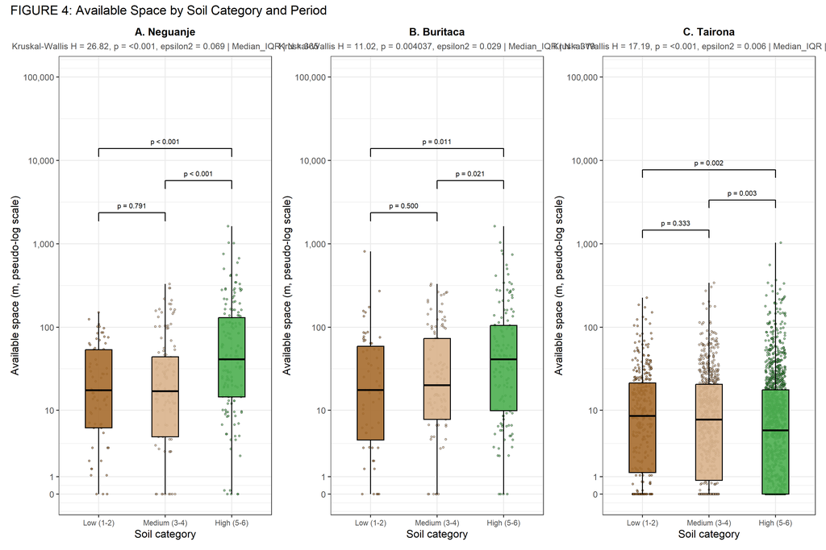

FIGURE 4: Available space by soil category and period. Boxplots show the distribution of inter-structure available space grouped into low (classes 1–2), medium (classes 3–4), and high (classes 5–6) suitability categories. All structures with available space equal to or greater than zero are included. All panels use the same pseudo-logarithmic vertical axis with fixed limits from 0 to 100,000 m. Pairwise significance brackets display Holm-adjusted Wilcoxon rank-sum p-values.

```r
soil_cat_colors <- c("Low (1-2)" = "#A66C2D", "Medium (3-4)" = "#D9B38C", "High (5-6)" = "#4CAF50")
soil_comparisons <- list(c("Low (1-2)", "Medium (3-4)"), c("Medium (3-4)", "High (5-6)"), c("Low (1-2)", "High (5-6)"))
df_all <- st_drop_geometry(all_structures) %>%
  filter(!is.na(Soil_Category), Available_Space >= 0)

create_soil_boxplot <- function(data, period_name, label) {
  df_period <- data %>% filter(Period == period_name)
  kw <- kruskal.test(Available_Space ~ Soil_Category, data = df_period)
  eps2 <- kw_epsilon_squared(kw, nrow(df_period), n_distinct(df_period$Soil_Category))
  auto <- select_drennan_summary(df_period$Available_Space)
  kw_text <- sprintf("Kruskal-Wallis H = %.2f, p = %s, epsilon2 = %.3f | %s | N = %d", as.numeric(kw$statistic), fmt_p(kw$p.value), eps2, auto$method, nrow(df_period))

  pw_raw <- pairwise.wilcox.test(df_period$Available_Space, df_period$Soil_Category, p.adjust.method = "none", exact = FALSE)
  pw_holm <- pairwise.wilcox.test(df_period$Available_Space, df_period$Soil_Category, p.adjust.method = "holm", exact = FALSE)
  raw_vec <- c(pw_raw$p.value["Medium (3-4)", "Low (1-2)"], pw_raw$p.value["High (5-6)", "Medium (3-4)"], pw_raw$p.value["High (5-6)", "Low (1-2)"])
  holm_vec <- c(pw_holm$p.value["Medium (3-4)", "Low (1-2)"], pw_holm$p.value["High (5-6)", "Medium (3-4)"], pw_holm$p.value["High (5-6)", "Low (1-2)"])

  holm_map <- function(p) {
    idx <- which.min(abs(raw_vec - p))
    hp <- holm_vec[idx]
    if (is.na(hp)) return("p = NA")
    if (hp < 0.001) "p < 0.001" else sprintf("p = %.3f", hp)
  }

  ggplot(df_period, aes(x = Soil_Category, y = Available_Space, fill = Soil_Category)) +
    geom_jitter(width = 0.15, size = 0.8, alpha = 0.5, shape = 21, color = "black") +
    geom_boxplot(width = 0.4, alpha = 0.9, color = "black", outlier.colour = "red", outlier.fill = "red", outlier.shape = 21, outlier.size = 1.5) +
    scale_fill_manual(values = soil_cat_colors) +
    geom_signif(comparisons = soil_comparisons, step_increase = 0.12, test = "wilcox.test", test.args = list(exact = FALSE), textsize = 2.5, map_signif_level = holm_map) +
    scale_y_continuous(
  trans = scales::pseudo_log_trans(base = 10),
  limits = c(0, 100000),
  breaks = c(0, 1, 10, 100, 1000, 10000, 100000),
  labels = scales::comma
) +
    labs(title = paste0(label, ". ", period_name), subtitle = kw_text, x = "Soil category", y = "Available space (m, pseudo-log scale)") +
    theme_bw() +
    theme(legend.position = "none", plot.title = element_text(face = "bold", size = 11, hjust = 0.5), plot.subtitle = element_text(size = 9, hjust = 0.5, color = "gray30"), axis.text.x = element_text(size = 8))
}

fig4 <- create_soil_boxplot(df_all, "Neguanje", "A") |
  create_soil_boxplot(df_all, "Buritaca", "B") |
  create_soil_boxplot(df_all, "Tairona", "C")
fig4 + plot_annotation(title = "FIGURE 4: Available Space by Soil Category and Period")
```

```r
cat("\nFIGURE 4 SCALE CHECK: all panels use pseudo-log vertical limits from 0 to 100000 m, with breaks at 0, 1, 10, 100, 1000, 10000, and 100000.\n")
```

```
##
## FIGURE 4 SCALE CHECK: all panels use pseudo-log vertical limits from 0 to 100000 m, with breaks at 0, 1, 10, 100, 1000, 10000, and 100000.
```

# 9 FIGURE 5: Neighborhood Infield Index

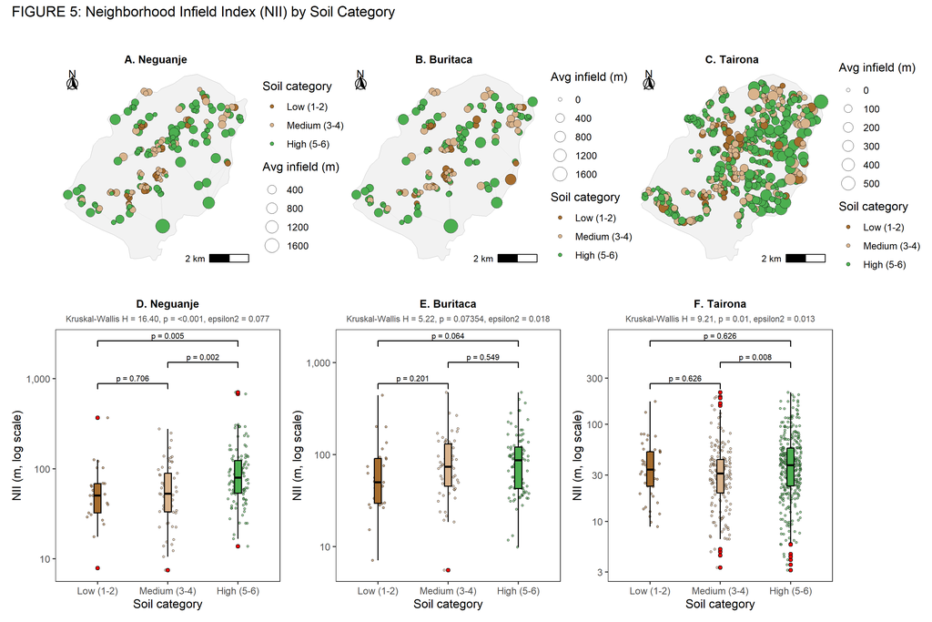

FIGURE 5: Neighborhood Infield Index using the primary mean-based site definition, with robust sensitivity printed below.

```r
build_site_network <- function(sites_sf, struc_sf, k = 3, use_robust_center = FALSE) {
  sites_valid <- sites_sf %>%
    st_make_valid() %>%
    mutate(Site_ID = row_number())
  centroids <- st_centroid(sites_valid)
  coords <- st_coordinates(centroids)
  struc_with_site <- st_join(struc_sf, sites_valid)

  center_fun <- if (use_robust_center) drennan_center else function(x) mean(x, na.rm = TRUE)

  site_metrics <- st_drop_geometry(struc_with_site) %>%
    filter(!is.na(Site_ID)) %>%
    group_by(Site_ID) %>%
    summarise(
      N_Structures = n(),
      Center_Avail_Space = center_fun(Available_Space),
      Mean_Avail_Space = mean(Available_Space, na.rm = TRUE),
      Mean_Soil_Quality = mean(Soil_Quality, na.rm = TRUE),
      .groups = "drop"
    ) %>%
    mutate(Dominant_Soil = case_when(
      Mean_Soil_Quality <= 2 ~ "Low (1-2)",
      Mean_Soil_Quality <= 4 ~ "Medium (3-4)",
      TRUE ~ "High (5-6)"
    ))

  sites_final <- sites_valid %>%
    inner_join(site_metrics, by = "Site_ID") %>%
    bind_cols(as.data.frame(coords[sites_valid$Site_ID %in% site_metrics$Site_ID, , drop = FALSE])) %>%
    rename(x = X, y = Y)

  n <- nrow(sites_final)
  if (n < 2) return(NULL)
  coords_final <- cbind(sites_final$x, sites_final$y)
  D <- as.matrix(dist(coords_final))
  diag(D) <- Inf
  adj <- matrix(FALSE, n, n)
  site_NII <- numeric(n)

  for (i in seq_len(n)) {
    k_eff <- min(k, n - 1)
    neighbors <- order(D[i, ])[seq_len(k_eff)]
    adj[i, neighbors] <- TRUE
    site_NII[i] <- mean(sites_final$Center_Avail_Space[neighbors], na.rm = TRUE)
  }

  adj <- adj | t(adj)
  list(sites_sf = sites_final, coords = coords_final, adj = adj, NII = site_NII)
}

net_neg_site <- build_site_network(sites_neg, struc_neg, k = 3, use_robust_center = FALSE)
net_bur_site <- build_site_network(sites_bur, struc_bur, k = 3, use_robust_center = FALSE)
net_tai_site <- build_site_network(sites_tai, struc_tai, k = 3, use_robust_center = FALSE)

plot_site_network <- function(net_result, survey_sf, period_name, label) {
  if (is.null(net_result)) return(ggplot() + theme_void())
  dat <- net_result$sites_sf
  coords <- net_result$coords
  adj <- net_result$adj
  edges_idx <- which(adj & upper.tri(adj), arr.ind = TRUE)
  edges_df <- data.frame(
    x = coords[edges_idx[, 1], 1],
    y = coords[edges_idx[, 1], 2],
    xend = coords[edges_idx[, 2], 1],
    yend = coords[edges_idx[, 2], 2]
  )
  nodes_df <- data.frame(
    x = coords[, 1],
    y = coords[, 2],
    Soil_Category = factor(dat$Dominant_Soil, levels = c("Low (1-2)", "Medium (3-4)", "High (5-6)")),
    Avg_Space = dat$Mean_Avail_Space
  )

  ggplot() +
    geom_sf(data = survey_sf, fill = "gray95", color = "gray70") +
    geom_segment(data = edges_df, aes(x = x, y = y, xend = xend, yend = yend), color = "gray70", linewidth = 0.1, alpha = 0.3) +
    geom_point(data = nodes_df, aes(x = x, y = y, fill = Soil_Category, size = Avg_Space), shape = 21, color = "black", stroke = 0.3) +
    scale_fill_manual(values = soil_cat_colors, name = "Soil category", drop = FALSE) +
    scale_size_continuous(range = c(1.5, 6), name = expression("Avg infield (m)")) +
    coord_sf(datum = NA) +
    ggspatial::annotation_north_arrow(location = "tl", style = north_arrow_fancy_orienteering(), height = unit(0.6, "cm"), width = unit(0.6, "cm")) +
    ggspatial::annotation_scale(location = "br", unit_category = "metric") +
    labs(title = paste0(label, ". ", period_name)) +
    theme_void() +
    theme(plot.title = element_text(face = "bold", hjust = 0.5, size = 10), legend.position = "right")
}

plot_site_NII_box <- function(net_result, period_name, label) {
  if (is.null(net_result)) return(ggplot() + theme_void())
  df <- data.frame(
    NII = net_result$NII,
    Soil_Category = factor(net_result$sites_sf$Dominant_Soil, levels = c("Low (1-2)", "Medium (3-4)", "High (5-6)"))
  ) %>%
    filter(!is.na(Soil_Category), !is.na(NII), NII > 0)

  kw <- kruskal.test(NII ~ Soil_Category, data = df)
  eps2 <- kw_epsilon_squared(kw, nrow(df), n_distinct(df$Soil_Category))
  kw_text <- sprintf("Kruskal-Wallis H = %.2f, p = %s, epsilon2 = %.3f", as.numeric(kw$statistic), fmt_p(kw$p.value), eps2)

  pw_raw <- pairwise.wilcox.test(df$NII, df$Soil_Category, p.adjust.method = "none", exact = FALSE)
  pw_holm <- pairwise.wilcox.test(df$NII, df$Soil_Category, p.adjust.method = "holm", exact = FALSE)
  raw_vec <- c(pw_raw$p.value["Medium (3-4)", "Low (1-2)"], pw_raw$p.value["High (5-6)", "Medium (3-4)"], pw_raw$p.value["High (5-6)", "Low (1-2)"])
  holm_vec <- c(pw_holm$p.value["Medium (3-4)", "Low (1-2)"], pw_holm$p.value["High (5-6)", "Medium (3-4)"], pw_holm$p.value["High (5-6)", "Low (1-2)"])
  holm_map <- function(p) {
    idx <- which.min(abs(raw_vec - p))
    hp <- holm_vec[idx]
    if (is.na(hp)) return("p = NA")
    if (hp < 0.001) "p < 0.001" else sprintf("p = %.3f", hp)
  }

  ggplot(df, aes(x = Soil_Category, y = NII, fill = Soil_Category)) +
    geom_jitter(width = 0.15, size = 0.8, alpha = 0.5, shape = 21, color = "black") +
    geom_boxplot(width = 0.1, alpha = 1, color = "black", outlier.colour = "black", outlier.fill = "red", outlier.shape = 21, outlier.size = 1.5) +
    scale_fill_manual(values = soil_cat_colors) +
    geom_signif(comparisons = soil_comparisons, step_increase = 0.12, test = "wilcox.test", test.args = list(exact = FALSE), textsize = 2.5, map_signif_level = holm_map) +
    scale_y_log10(labels = scales::comma) +
    labs(title = paste0(label, ". ", period_name), subtitle = kw_text, x = "Soil category", y = "NII (m, log scale)") +
    theme_bw() +
    theme(legend.position = "none", plot.title = element_text(face = "bold", size = 10, hjust = 0.5), plot.subtitle = element_text(size = 8, hjust = 0.5, color = "gray30"), panel.grid.major = element_blank(), panel.grid.minor = element_blank())
}

fig5 <- (plot_site_network(net_neg_site, survey_sf, "Neguanje", "A") | plot_site_network(net_bur_site, survey_sf, "Buritaca", "B") | plot_site_network(net_tai_site, survey_sf, "Tairona", "C")) /
  (plot_site_NII_box(net_neg_site, "Neguanje", "D") | plot_site_NII_box(net_bur_site, "Buritaca", "E") | plot_site_NII_box(net_tai_site, "Tairona", "F")) +
  plot_annotation(title = "FIGURE 5: Neighborhood Infield Index (NII) by Soil Category")
print(fig5)
```

```r
cat("\nFIGURE 5 NUMERICAL SUMMARY, PRIMARY MEAN-BASED NII (k=3):\n")
```

FIGURE 5 NUMERICAL SUMMARY, PRIMARY MEAN-BASED NII (k=3):

```r
net_list <- list(net_neg_site, net_bur_site, net_tai_site)
for (i in seq_along(periods)) {
  net_data <- net_list[[i]]
  if (!is.null(net_data)) {
    df_s <- net_data$sites_sf %>%
      mutate(NII = net_data$NII) %>%
      st_drop_geometry() %>%
      filter(!is.na(Dominant_Soil), !is.na(NII))
    sp <- suppressWarnings(cor.test(df_s$Mean_Soil_Quality, df_s$NII, method = "spearman", exact = FALSE))
    kw <- kruskal.test(NII ~ Dominant_Soil, data = df_s)
    eps2 <- kw_epsilon_squared(kw, nrow(df_s), n_distinct(df_s$Dominant_Soil))
    stats <- df_s %>%
      group_by(Dominant_Soil) %>%
      summarise(n = n(), mean_NII = mean(NII), median_NII = median(NII), iqr_NII = IQR(NII), .groups = "drop")
    cat(sprintf("\n%s (N=%d): rho=%.4f, p=%s | KW H=%.2f, p=%s, epsilon2=%.4f\n", toupper(periods[i]), nrow(df_s), as.numeric(sp$estimate), fmt_p(sp$p.value), as.numeric(kw$statistic), fmt_p(kw$p.value), eps2))
    for (j in seq_len(nrow(stats))) {
      cat(sprintf("%s: n=%d, mean=%.1f, median=%.1f, IQR=%.1f\n", stats$Dominant_Soil[j], stats$n[j], stats$mean_NII[j], stats$median_NII[j], stats$iqr_NII[j]))
    }
  }
}
```

NEGUANJE (N=190): rho=0.2745, p=<0.001 | KW H=16.40, p=<0.001, epsilon2=0.0770 High (5-6): n=108, mean=108.6, median=79.6, IQR=70.2 Low (1-2): n=25, mean=67.2, median=50.5, IQR=36.1 Medium (3-4): n=57, mean=69.9, median=52.9, IQR=55.9

BURITACA (N=178): rho=0.1290, p=0.08625 | KW H=5.22, p=0.07354, epsilon2=0.0184 High (5-6): n=94, mean=101.7, median=86.7, IQR=77.4 Low (1-2): n=27, mean=78.4, median=49.8, IQR=61.1 Medium (3-4): n=57, mean=92.4, median=73.6, IQR=84.9

TAIRONA (N=551): rho=0.1419, p=<0.001 | KW H=9.21, p=0.01, epsilon2=0.0132 High (5-6): n=328, mean=47.7, median=37.9, IQR=33.7 Low (1-2): n=49, mean=41.0, median=34.2, IQR=29.3 Medium (3-4): n=174, mean=39.2, median=31.0, IQR=23.8

```r
cat("\nROBUST NII SENSITIVITY, NOT USED FOR THE MAIN FIGURE:\n")
```

ROBUST NII SENSITIVITY, NOT USED FOR THE MAIN FIGURE:

```r
net_neg_rob <- build_site_network(sites_neg, struc_neg, k = 3, use_robust_center = TRUE)
net_bur_rob <- build_site_network(sites_bur, struc_bur, k = 3, use_robust_center = TRUE)
net_tai_rob <- build_site_network(sites_tai, struc_tai, k = 3, use_robust_center = TRUE)
net_rob_list <- list(net_neg_rob, net_bur_rob, net_tai_rob)
for (i in seq_along(periods)) {
  net_data <- net_rob_list[[i]]
  if (!is.null(net_data)) {
    df_s <- net_data$sites_sf %>%
      mutate(NII = net_data$NII) %>%
      st_drop_geometry() %>%
      filter(!is.na(Dominant_Soil), !is.na(NII))
    kw <- kruskal.test(NII ~ Dominant_Soil, data = df_s)
    eps2 <- kw_epsilon_squared(kw, nrow(df_s), n_distinct(df_s$Dominant_Soil))
    cat(sprintf("%s robust sensitivity: KW H=%.2f, p=%s, epsilon2=%.4f\n", periods[i], as.numeric(kw$statistic), fmt_p(kw$p.value), eps2))
  }
}
```

Neguanje robust sensitivity: KW H=16.98, p=<0.001, epsilon2=0.0801 Buritaca robust sensitivity: KW H=6.24, p=0.04412, epsilon2=0.0242 Tairona robust sensitivity: KW H=7.54, p=0.02309, epsilon2=0.0101

# 10 FIGURE 6: L-Function

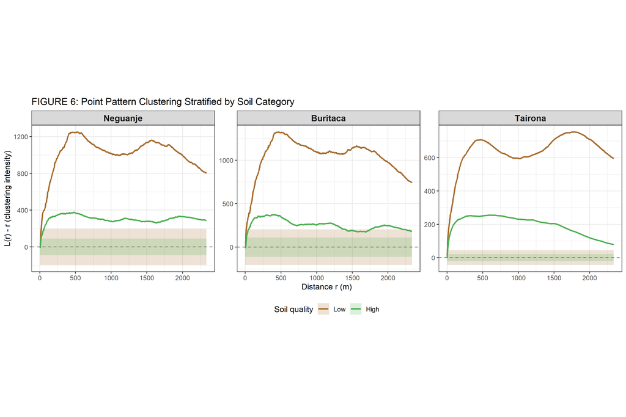

FIGURE 6: Centered L-function stratified by low and high soil quality. The panels use period-specific vertical scales to preserve within-period curve legibility. Cross-period comparison should therefore rely on the reported peak L(r) values and associated distances in the numerical summary, rather than on visual curve height alone.

```r
compute_L_centered <- function(struc_sf, survey_sf, soil_group, period_name, nsim = 99) {
  struc_sub <- if (soil_group == "High") {
    struc_sf %>% filter(Soil_Quality >= 5)
  } else {
    struc_sf %>% filter(Soil_Quality <= 2)
  }
  if (nrow(struc_sub) < 10) {
    return(data.frame(r = NA, L_val = NA, L_lo = NA, L_hi = NA, Period = period_name, Soil_Group = soil_group))
  }
  coords <- st_coordinates(struc_sub)
  W <- as.owin(st_geometry(survey_sf))
  pp <- ppp(x = coords[, 1], y = coords[, 2], window = W)
  env <- tryCatch(
    envelope(pp, fun = Lest, nsim = nsim, correction = "isotropic", global = TRUE, savefuns = TRUE, verbose = FALSE),
    error = function(e) NULL
  )
  if (is.null(env)) {
    return(data.frame(r = NA, L_val = NA, L_lo = NA, L_hi = NA, Period = period_name, Soil_Group = soil_group))
  }
  data.frame(
    r = env$r,
    L_val = env$obs - env$r,
    L_lo = env$lo - env$r,
    L_hi = env$hi - env$r,
    Period = period_name,
    Soil_Group = soil_group
  )
}

L_data <- bind_rows(
  compute_L_centered(struc_neg, survey_sf, "High", "Neguanje"),
  compute_L_centered(struc_neg, survey_sf, "Low", "Neguanje"),
  compute_L_centered(struc_bur, survey_sf, "High", "Buritaca"),
  compute_L_centered(struc_bur, survey_sf, "Low", "Buritaca"),
  compute_L_centered(struc_tai, survey_sf, "High", "Tairona"),
  compute_L_centered(struc_tai, survey_sf, "Low", "Tairona")
) %>%
  filter(!is.na(r))

L_data$Period <- factor(L_data$Period, levels = periods)
L_data$Soil_Group <- factor(L_data$Soil_Group, levels = c("Low", "High"))

fig6 <- ggplot(L_data, aes(x = r)) +
  geom_ribbon(aes(ymin = L_lo, ymax = L_hi, fill = Soil_Group), alpha = 0.2) +
  geom_line(aes(y = L_val, color = Soil_Group), linewidth = 1) +
  geom_hline(yintercept = 0, linetype = "dashed", color = "gray40") +
  facet_wrap(~ Period, scales = "free_y", ncol = 3) +
  scale_color_manual(values = c("Low" = "#A66C2D", "High" = "#4CAF50"), name = "Soil quality") +
  scale_fill_manual(values = c("Low" = "#A66C2D", "High" = "#4CAF50"), name = "Soil quality") +
  labs(title = "FIGURE 6: Point Pattern Clustering Stratified by Soil Category", x = "Distance r (m)", y = "L(r) - r (clustering intensity)") +
  theme_bw() +
  theme(aspect.ratio = 0.8, legend.position = "bottom", strip.text = element_text(face = "bold", size = 12))
print(fig6)
```

```r
cat("\nFIGURE 6 NUMERICAL SUMMARY:\n")
```

FIGURE 6 NUMERICAL SUMMARY:

```r
for (period in periods) {
  for (sg in c("Low", "High")) {
    sub <- L_data %>% filter(Period == period, Soil_Group == sg, !is.na(L_val))
    if (nrow(sub) > 0) {
      n_s <- ifelse(
        sg == "High",
        sum(data_by_period[[period]]$structures$Soil_Quality >= 5, na.rm = TRUE),
        sum(data_by_period[[period]]$structures$Soil_Quality <= 2, na.rm = TRUE)
      )
      cat(sprintf("%s - %s (n=%d): peak=%.1f at r=%.0f m, mean=%.1f\n", period, sg, n_s, max(sub$L_val), sub$r[which.max(sub$L_val)], mean(sub$L_val)))
    }
  }
}
```

Neguanje - Low (n=73): peak=1251.0 at r=520 m, mean=1013.4 Neguanje - High (n=164): peak=378.6 at r=470 m, mean=305.0 Buritaca - Low (n=63): peak=1325.6 at r=465 m, mean=1046.8 Buritaca - High (n=143): peak=375.2 at r=397 m, mean=255.6 Tairona - Low (n=349): peak=755.0 at r=1788 m, mean=641.1 Tairona - High (n=1447): peak=255.1 at r=607 m, mean=195.5

# 11 FIGURE 7: Multidimensional Scaling

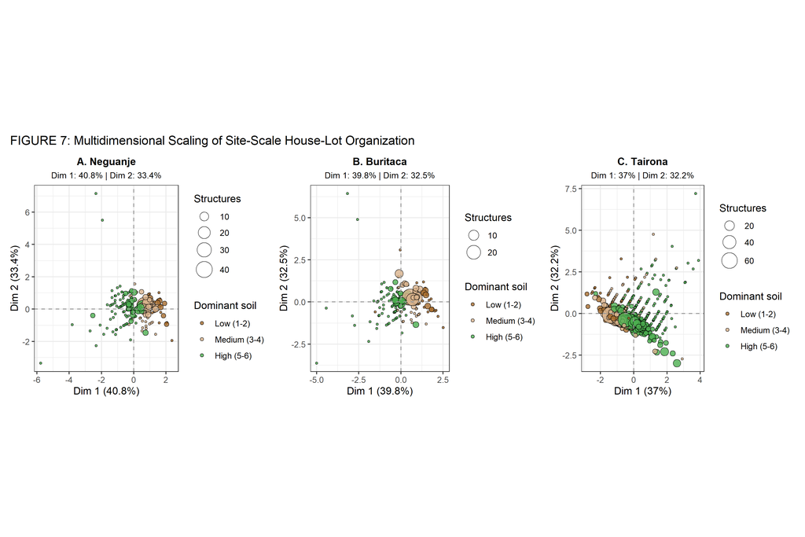

FIGURE 7: Multidimensional scaling of site-scale house-lot organization using the primary mean-based aggregation.

```r
compute_site_metrics_with_soil <- function(sites_sf, struc_sf, period_name, use_robust_center = FALSE) {
  sites_sf <- st_make_valid(sites_sf)
  sites_b <- st_buffer(sites_sf, dist = 1)
  im <- st_intersects(struc_sf, sites_b, sparse = FALSE)
  ns <- colSums(im)
  md <- mn <- ms <- numeric(nrow(sites_sf))
  ds <- character(nrow(sites_sf))
  center_fun <- if (use_robust_center) drennan_center else function(x) mean(x, na.rm = TRUE)

  for (j in seq_len(nrow(sites_sf))) {
    idx <- which(im[, j])
    if (length(idx) > 0) {
      md[j] <- center_fun(struc_sf$Diam_Terra[idx])
      mn[j] <- center_fun(struc_sf$NNDist[idx])
      ms[j] <- center_fun(struc_sf$Soil_Quality[idx])
      ds[j] <- if (ms[j] <= 2) "Low (1-2)" else if (ms[j] <= 4) "Medium (3-4)" else "High (5-6)"
    } else {
      md[j] <- NA
      mn[j] <- NA
      ms[j] <- NA
      ds[j] <- NA
    }
  }

  sdf <- st_drop_geometry(sites_sf)
  sdf$N_Structures <- ns
  sdf$Center_Diam_Terra <- md
  sdf$Center_NNDist <- mn
  sdf$Center_Soil_Quality <- ms
  sdf$Dominant_Soil <- factor(ds, levels = c("Low (1-2)", "Medium (3-4)", "High (5-6)"))
  sdf$Period <- period_name
  sdf
}

sm_neg <- compute_site_metrics_with_soil(sites_neg, struc_neg, "Neguanje", use_robust_center = FALSE)
sm_bur <- compute_site_metrics_with_soil(sites_bur, struc_bur, "Buritaca", use_robust_center = FALSE)
sm_tai <- compute_site_metrics_with_soil(sites_tai, struc_tai, "Tairona", use_robust_center = FALSE)

create_mds_panel <- function(sm, period_name, label) {
  v <- sm %>%
    filter(N_Structures > 0, is.finite(Center_Diam_Terra), is.finite(Center_NNDist), is.finite(Center_Soil_Quality)) %>%
    select(N_Structures, Center_Diam_Terra, Center_NNDist, Center_Soil_Quality, Dominant_Soil)

  if (nrow(v) < 5) return(ggplot() + theme_void())

  m <- scale(v %>% select(Center_Diam_Terra, Center_NNDist, Center_Soil_Quality))
  r <- cmdscale(dist(m), k = 2, eig = TRUE)
  ve <- round(r$eig[1:2] / sum(abs(r$eig)) * 100, 1)
  d <- data.frame(D1 = r$points[, 1], D2 = r$points[, 2], N = v$N_Structures, Soil = v$Dominant_Soil)

  ggplot(d, aes(x = D1, y = D2)) +
    geom_point(aes(size = N, fill = Soil), color = "black", shape = 21, stroke = 0.5, alpha = 0.8) +
    geom_hline(yintercept = 0, linetype = "dashed", color = "gray60") +
    geom_vline(xintercept = 0, linetype = "dashed", color = "gray60") +
    scale_size_continuous(range = c(1, 8), name = "Structures") +
    scale_fill_manual(values = soil_cat_colors, name = "Dominant soil", drop = FALSE) +
    labs(title = paste0(label, ". ", period_name), subtitle = paste0("Dim 1: ", ve[1], "% | Dim 2: ", ve[2], "%"), x = paste0("Dim 1 (", ve[1], "%)"), y = paste0("Dim 2 (", ve[2], "%)")) +
    theme_bw() +
    theme(plot.title = element_text(face = "bold", size = 11, hjust = 0.5), plot.subtitle = element_text(size = 9, hjust = 0.5), legend.position = "right") +
    coord_fixed()
}

fig7 <- create_mds_panel(sm_neg, "Neguanje", "A") |
  create_mds_panel(sm_bur, "Buritaca", "B") |
  create_mds_panel(sm_tai, "Tairona", "C")
fig7 + plot_annotation(title = "FIGURE 7: Multidimensional Scaling of Site-Scale House-Lot Organization")
```

```r
cat("\nFIGURE 7 NUMERICAL SUMMARY, PRIMARY MEAN-BASED MDS:\n")
```

FIGURE 7 NUMERICAL SUMMARY, PRIMARY MEAN-BASED MDS:

```r
for (item in list(list(d = sm_neg, n = "NEGUANJE"), list(d = sm_bur, n = "BURITACA"), list(d = sm_tai, n = "TAIRONA"))) {
  v <- item$d %>%
    filter(N_Structures > 0, is.finite(Center_Diam_Terra), is.finite(Center_NNDist), is.finite(Center_Soil_Quality))
  st <- v %>%
    group_by(Dominant_Soil) %>%
    summarise(
      n = n(),
      diameter = mean(Center_Diam_Terra),
      nnd = mean(Center_NNDist),
      soil = mean(Center_Soil_Quality),
      structures = mean(N_Structures),
      .groups = "drop"
    )
  r <- cmdscale(dist(scale(v %>% select(Center_Diam_Terra, Center_NNDist, Center_Soil_Quality))), k = 2, eig = TRUE)
  ve <- round(r$eig[1:2] / sum(abs(r$eig)) * 100, 1)
  cat(sprintf("\n%s (N=%d):\n", item$n, nrow(v)))
  for (j in seq_len(nrow(st))) {
    cat(sprintf("%s: n=%d, diameter=%.1f, NND=%.1f, soil=%.2f, structures=%.1f\n", st$Dominant_Soil[j], st$n[j], st$diameter[j], st$nnd[j], st$soil[j], st$structures[j]))
  }
  cat(sprintf("Variance: Dim1=%.1f%%, Dim2=%.1f%%\n", ve[1], ve[2]))
}
```

NEGUANJE (N=190): Low (1-2): n=25, diameter=10.4, NND=77.8, soil=1.49, structures=1.4 Medium (3-4): n=57, diameter=10.2, NND=91.6, soil=3.43, structures=2.9 High (5-6): n=108, diameter=10.8, NND=172.0, soil=5.54, structures=1.5 Variance: Dim1=40.8%, Dim2=33.4%

BURITACA (N=178): Low (1-2): n=27, diameter=10.4, NND=109.5, soil=1.56, structures=1.4 Medium (3-4): n=57, diameter=10.6, NND=105.1, soil=3.52, structures=2.6 High (5-6): n=94, diameter=10.8, NND=173.9, soil=5.55, structures=1.4 Variance: Dim1=39.8%, Dim2=32.5%

TAIRONA (N=551): Low (1-2): n=49, diameter=10.7, NND=71.7, soil=1.63, structures=1.7 Medium (3-4): n=174, diameter=10.6, NND=51.4, soil=3.39, structures=4.8 High (5-6): n=328, diameter=10.9, NND=60.7, soil=5.45, structures=4.9 Variance: Dim1=37.0%, Dim2=32.2%

```r
cat("\nROBUST MDS SENSITIVITY, NOT USED FOR THE MAIN FIGURE:\n")
```

ROBUST MDS SENSITIVITY, NOT USED FOR THE MAIN FIGURE:

```r
sm_neg_rob <- compute_site_metrics_with_soil(sites_neg, struc_neg, "Neguanje", use_robust_center = TRUE)
sm_bur_rob <- compute_site_metrics_with_soil(sites_bur, struc_bur, "Buritaca", use_robust_center = TRUE)
sm_tai_rob <- compute_site_metrics_with_soil(sites_tai, struc_tai, "Tairona", use_robust_center = TRUE)
for (item in list(list(d = sm_neg_rob, n = "NEGUANJE"), list(d = sm_bur_rob, n = "BURITACA"), list(d = sm_tai_rob, n = "TAIRONA"))) {
  v <- item$d %>%
    filter(N_Structures > 0, is.finite(Center_Diam_Terra), is.finite(Center_NNDist), is.finite(Center_Soil_Quality))
  r <- cmdscale(dist(scale(v %>% select(Center_Diam_Terra, Center_NNDist, Center_Soil_Quality))), k = 2, eig = TRUE)
  ve <- round(r$eig[1:2] / sum(abs(r$eig)) * 100, 1)
  cat(sprintf("%s robust sensitivity: N=%d, Dim1=%.1f%%, Dim2=%.1f%%\n", item$n, nrow(v), ve[1], ve[2]))
}
```

NEGUANJE robust sensitivity: N=190, Dim1=40.6%, Dim2=33.3% BURITACA robust sensitivity: N=178, Dim1=39.5%, Dim2=32.5% TAIRONA robust sensitivity: N=551, Dim1=37.1%, Dim2=32.0%